# Monitoreo mensual del empleo de plataformas digitales

Hacia una regulación laboral efectiva para los trabajadores de plataformas digitales

Autor/a

Nicolás Ratto

Fecha de publicación

2 de agosto de 2026

# 1 Introducción

El presente documento consiste en un monitoreo mensual del empleo en el sector de las plataformas digitales de Chile, en base a la Encuesta Nacional de Empleo del Instituto Nacional de Estadísticas (INE). Esto, para el proyecto *Hacia una regulación laboral efectiva para los trabajadores de plataformas digitales*, en cooperación con la Fundación Friedrich Ebert en Chile.

# 2 Plataformas digitales

A todas las personas que reportan estar ocupadas en la semana de referencia, el INE les consulta si realizaron su trabajo a través de una plataforma digital de servicio: *¿Su trabajo lo realiza a través de una aplicación móvil o plataforma web?*. Si la respuesta es afirmativa, la persona debe indicar el nombre de la plataforma. Así, se puede obtener un listado con las plataformas digitales más recurrentes. La siguiente tabla muestra las 10 más nombradas desde el 2020 a la fecha. La de mayor prevalencia es *Instagram*, que en promedio cada mes es utilizada por más de 50.000 personas para realizar su trabajo. Luego viene *Facebook*, *Whatsapp* y *Uber*, con más de 30.000 personas cada una. Con una mucho menor prevalencia luego viene *Marketplace* de *Facebook*, *Uber Eats* y *PedidosYa*.

Tabla 1: Principales empresas de plataformas reportadas (promedio ocupados mensuales)

| Plataformas | Ocupados mensualizado |
| --- | --- |
| INSTAGRAM | 50.865 |
| FACEBOOK | 36.336 |
| WHATSAPP | 32.371 |
| UBER | 31.106 |
| FACEBOOK MARKETPLACE | 6.716 |
| FACEBOOK INSTAGRAM | 5.528 |
| INSTAGRAM FACEBOOK | 3.986 |
| UBER EATS | 3.711 |
| PEDIDOS YA | 3.536 |
| CORNERSHOP | 3.300 |

Quienes declaran realizar su trabajo a través de una plataforma digital sumaron más de 365.831 personas el último trimestre móvil reportado por el INE. Las personas ocupadas que utilizan alguna de estas plataformas viene aumentando continuamente desde que existe registro, desde el año 2020. Respecto de hace una año, los ocupados de plataformas aumentaron en 81.308 personas.

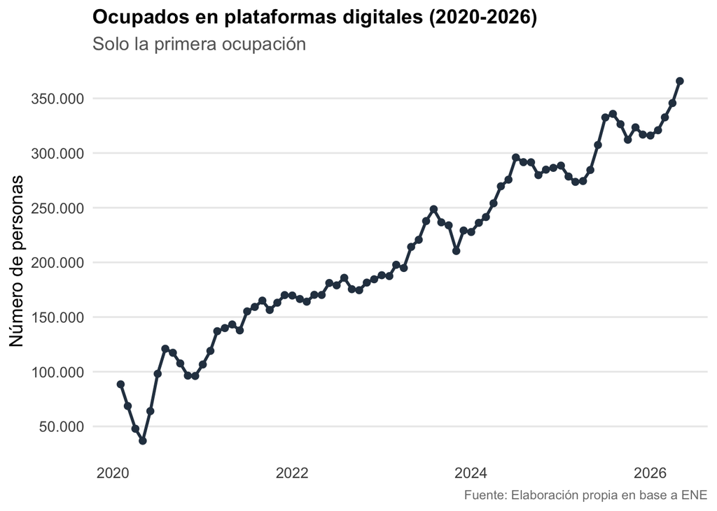

# 3 Plataformas digitales georreferenciadas (Ley 21.431)

Tabla 2: Principales empresas de plataformas reportadas, Ley 21431

| Plataformas | Ocupados mensualizado |
| --- | --- |
| UBER | 31.106 |
| UBER EATS | 3.711 |
| PEDIDOS YA | 3.536 |
| CORNERSHOP | 3.300 |
| MERCADOLIBRE | 2.415 |
| DIDI | 2.242 |
| RAPPI | 2.203 |
| INDRIVE | 2.184 |
| UBER EATS UBER | 860 |
| CABIFY | 694 |

Más allá de la relevancia de seguir el empleo de quienes utilizan plataformas digitales, sin importar su tipo, podemos filtrar las empresas de plataformas digitales para quedarnos con un subconjunto de interés. En este caso, las plataformas reguladas por la Ley 21.431, como *Uber* o *PedidosYa*, que intermedian el trabajo georreferenciado. Para esto, quitamos a las plataformas de redes sociales, como *Instagram* y *Facebook*, así como a las plataformas de creación y difusión de contenido, como *Youtube* y *OnlyFans*. En el último trimestre registrado, estos trabajadores alcanzaron las 82.798 personas (solo considerando quienes se ocupan en plataformas digitales reguladas por la Ley 21.431 como primera ocupación). En el último año, estos trabajaron aumentaron en 8.339 personas.

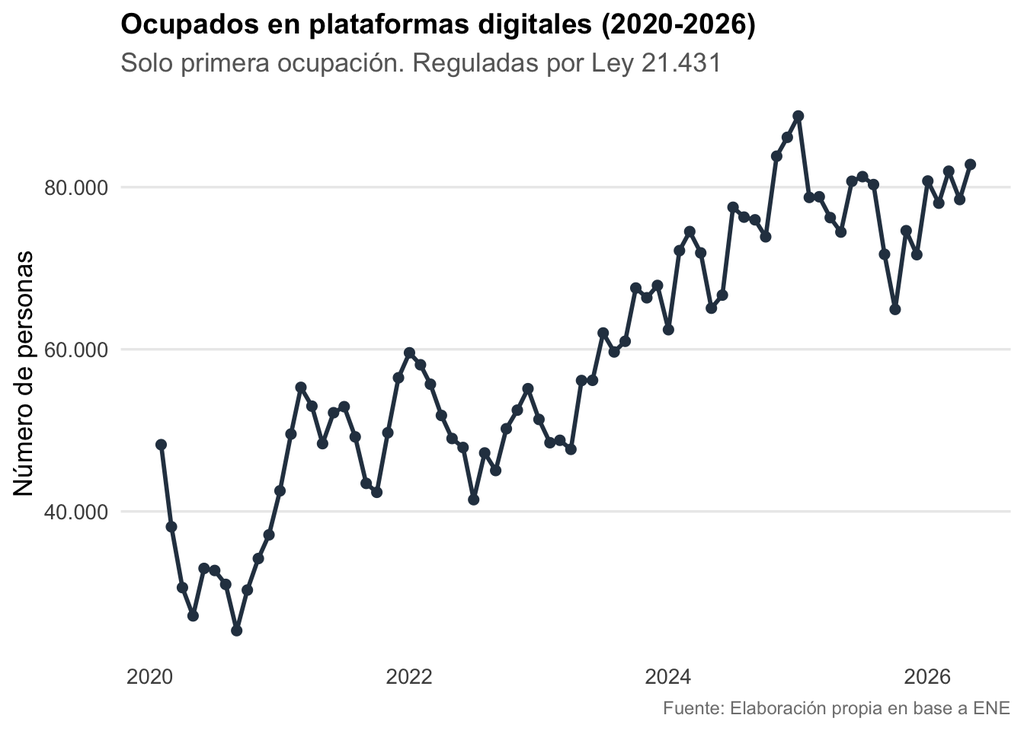

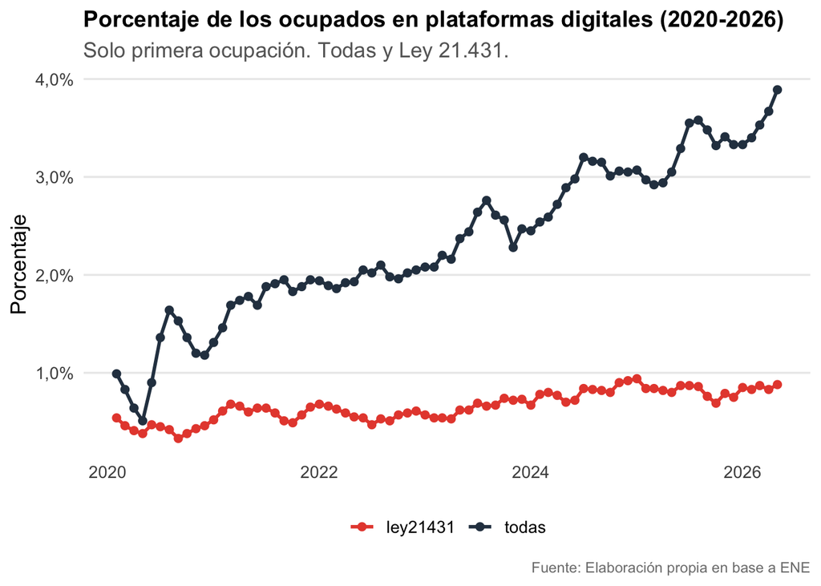

## 3.1 Características sociodemográficas

### 3.1.1 Sexo

La distribución por sexo entre 2020 y 2026 evidencia una marcada masculinización de la fuerza laboral en plataformas digitales reguladas por la Ley 21.431: los hombres representan en promedio un 85,63% de los trabajadores, frente a un 14,37% de mujeres (Tabla 3).

Tabla 3: Promedio de distribución por sexo (2020-2026)

| sexo | percent |
| --- | --- |
| hombre | 85.63 |
| mujer | 14.37 |

### 3.1.2 Región

Tabla 4: Promedio de distribución por región últimos 12 meses

| region | percent |
| --- | --- |
| 1 Tarapacá | 2.23 |
| 2 Antofagasta | 2.34 |
| 3 Atacama | 0.93 |
| 4 Coquimbo | 4.58 |
| 5 Valparaíso | 8.97 |
| 6 O’Higgins | 1.39 |
| 7 Maule | 3.50 |
| 8 Biobío | 6.48 |
| 9 La Araucanía | 2.95 |
| 10 Los Lagos | 2.95 |
| 11 Aysén | 0.19 |
| 12 Magallanes | 0.94 |
| 13 Metropolitana | 58.85 |
| 14 Los Ríos | 1.11 |
| 15 Arica y Parinacota | 1.43 |
| 16 Ñuble | 1.21 |

### 3.1.3 Nacionalidad

La distribución por nacionalidad de trabajadores de plataformas digitales en el período 2025-2026 muestra que la nacionalidad chilena representa el 62,69% del total, seguida por Venezuela (26,32%) y Colombia (4,86%). Estas tres nacionalidades en conjunto representan el 93,87% de los trabajadores de plataformas digitales en el período analizado. Las otras nacionalidades no se presentan en Tabla 5. En comparación con el período 2022-2023, la participación chilena aumentó más de tres puntos porcentuales, la colombiana aumentó menos de un punto y la participación venezolana disminuyó más de 7 puntos.

Tabla 5: Promedio de distribución por nacionalidad últimos 12 meses. 3 principales

| nacionalidad | 2022-2023 | 2025-2026 |
| --- | --- | --- |
| Chilena (152) | 59.48 | 62.69 |
| Colombia (170) | 4.12 | 4.86 |
| Venezuela (862) | 33.73 | 26.32 |

### 3.1.4 Edad

Tabla 6: Promedio de distribución por edad últimos 12 meses

| tramo_edad | percent | percent_acum |
| --- | --- | --- |
| 15 a 19 años | 1.3 | 1.3 |
| 20 a 24 años | 5.5 | 6.8 |
| 25 a 29 años | 14.0 | 20.8 |
| 30 a 34 años | 23.9 | 44.7 |
| 35 a 39 años | 19.4 | 64.1 |
| 40 a 44 años | 11.0 | 75.1 |
| 45 a 49 años | 8.1 | 83.2 |
| 50 a 54 años | 6.3 | 89.5 |
| 55 a 59 años | 5.1 | 94.6 |
| 60 a 64 años | 3.5 | 98.1 |
| 65 a 69 años | 0.8 | 98.9 |
| 70 años o más | 1.2 | 100.1 |

## 3.2 Características de la ocupación

### 3.2.1 Informalidad

El quiebre más marcado se observa desde mediados de 2024: la informalidad cae de niveles cercanos al 69% (enero 2024) a mínimos históricos de 56,29% (septiembre 2025), coincidiendo con la entrada en régimen de las resoluciones del Servicio de Impuestos Internos (SII) que hacen operativos algunos aspectos de la Ley 21.431. Este período (2024-2025) concentra la mayor parte de la reducción observada en toda la serie. Sin embargo, hacia el cierre de la serie disponible se aprecia un repunte a 62.53%, lo que sugiere que la formalización no ha sido un proceso lineal ni necesariamente consolidado, y amerita monitoreo continuo (véase la Tabla 7).

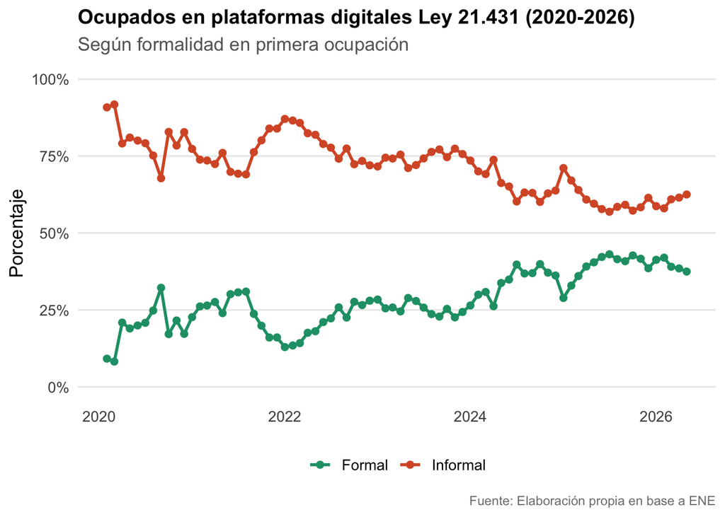

Tabla 7: Distribución por formalidad en último periodo con datos

| periodo | ocup_form | ocupados | percent |
| --- | --- | --- | --- |
| 2026-05-01 | Formales | 31.022 | 37.47 |
| 2026-05-01 | Informales | 51.776 | 62.53 |

### 3.2.2 Ocupación

La mayoría de los trabajadores (83,6%) son clasificados en la categoría CIUO 8 “Operadores de instalaciones y máquinas y ensambladores”[^1], en las que se encuentran las ocupaciones vinculadas a conductores y repartidores:

- 8321 Conductores de motocicletas.
- 8322 Conductores de automóviles, taxis y camionetas.

Tabla 8: Distribución por ocupación (CIUO) en los últimos 12 meses

| b1_glosa | percent |
| --- | --- |
| Operadores de instalaciones y máquinas y ensambladores | 83.6 |
| Trabajadores de los servicios y vendedores de comercios y mercados | 8.2 |
| Ocupaciones elementales | 3.1 |
| Directores y gerentes | 1.6 |
| Profesionales científicos e intelectuales | 1.5 |
| Técnicos y profesionales de nivel medio | 0.9 |
| Oficiales, operarios y artesanos de artes mecánicas y de otros oficios | 0.7 |
| Agricultores y trabajadores calificados agropecuarios, forestales y pesqueros | 0.4 |
| Personal de apoyo administrativo | 0.4 |

### 3.2.3 Categoría en la ocupación

Tabla 9: Distribución por categoría en la ocupación en los últimos 12 meses

| categoria_ocupacion | percent |
| --- | --- |
| Cuenta propia | 87.3 |
| Asalariado/a del sector privado | 10.2 |
| Empleador/a | 2.5 |

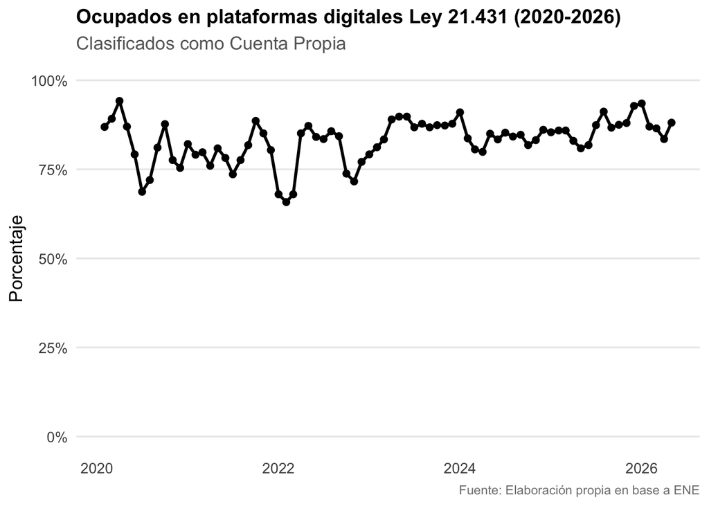

## 3.3 Salarios en 2025

La Encuesta Nacional de Empleo no incluye por si misma preguntas sobre salarios. La información debe ser complementada por la Encuesta Suplementaria de Ingresos, cuyos últimos datos publicados corresponden al trimestre móvil octubre - noviembre - diciembre de 2025. En ese trimestre se registraron 74.629 trabajadores de plataformas digitales regulados por la Ley 21.431 (ocupando factores de expansión de la ESI), que corresponden a 219 personas en la muestra. El ingreso mensual promedio que estos trabajadores recibieron por su ocupación principal fue de $668.045. La mediana salarial fue de $528.399, lo que indica que la mitad de los trabajadores recibió ese monto o menos.

Tabla 10: Ingreso del trabajo promedio y mediano en 2025 para los trabajadores de plataformas

| salario_promedio | salario_mediano |
| --- | --- |
| $668.045 | $528.399 |

En términos agregados, las dos medidas de ingresos del trabajo superaron el ingreso mínimo mensual de ese momento, $529.000 ($430.077 neto, considerando los descuentos legales). Sin embargo, es necesario observar el ingreso por hora, cuyo valor de referencia mínimo neto sería de $2.444. Con el recargo del 20% establecido por la Ley 21.431 el monto de referencia quedaría en $2.932. En promedio, los trabajadores de plataformas digitales trabajaron 151.5 horas en el trimestre de referencia, alcanzando un ingreso promedio por hora de $3.741, $809 más que el mínimo legal.

Considérese que solamente 28 casos presentaron información válida para hacer la estimación, por lo que los intervalos de confianza de los estadísitcos son especialmente amplios. En el caso de la media, estos van desde los $2.913 a los $4.568, mientras que en el caso de la mediana van desde los $2.660 a los $5.315. Así, las estimaciones de los ingresos promedio por hora de los trabajadores de plataformas no son estadísticamente superiores a los montos establecidos por ley.

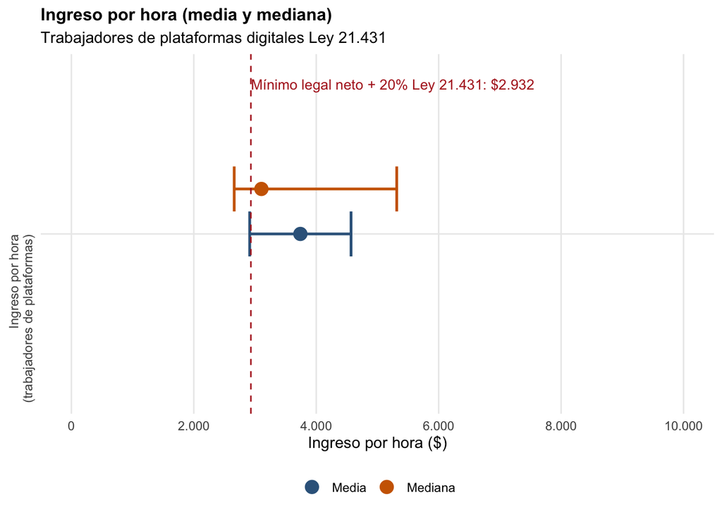

# 4 Plataformas digitales georreferenciadas como segunda ocupación

En la Tabla 11 se pueden observar las distintas plataformas digitales que los trabajadores que declaran tener una segunda ocupación reportan, entre las que destacan Uber y Uber Eats. En total, los ocupados que reportan tener una segunda ocupación en plataformas digitales reguladas por la Ley 21.431 promedian las 5.580 personas mensuales. Para el último trimestre con datos, estas personas suman 17.101.

Tabla 11: Principales empresas de plataformas reportadas, Ley 21431 (segunda ocupación)

| Plataformas | Ocupados mensualizado |
| --- | --- |
| UBER | 3.052 |
| UBER EATS | 564 |
| CORNERSHOP | 385 |
| INDRIVE | 316 |
| MERCADOLIBRE | 285 |
| PEDIDOS YA | 256 |
| RAPPI | 215 |
| CABIFY | 169 |
| DIDI | 169 |
| UBER DIDI | 98 |

A continuación se presentan tres series históricas de interés: trabajadores que en su primera ocupación reportan trabajar en plataformas digitales reguladas por la Ley 21.431 (serie roja); trabajadores que lo reportan en su segunda ocupación (serie negra); y la suma de trabajadores que lo reportan en su primera o segunda ocupación (serie morada). En el último trimestre con datos los trabajadores que reportan trabajar en plataformas digitales reguladas por la Ley 21.431 como primera o segunda ocupación alcanzan las 99.898 personas.

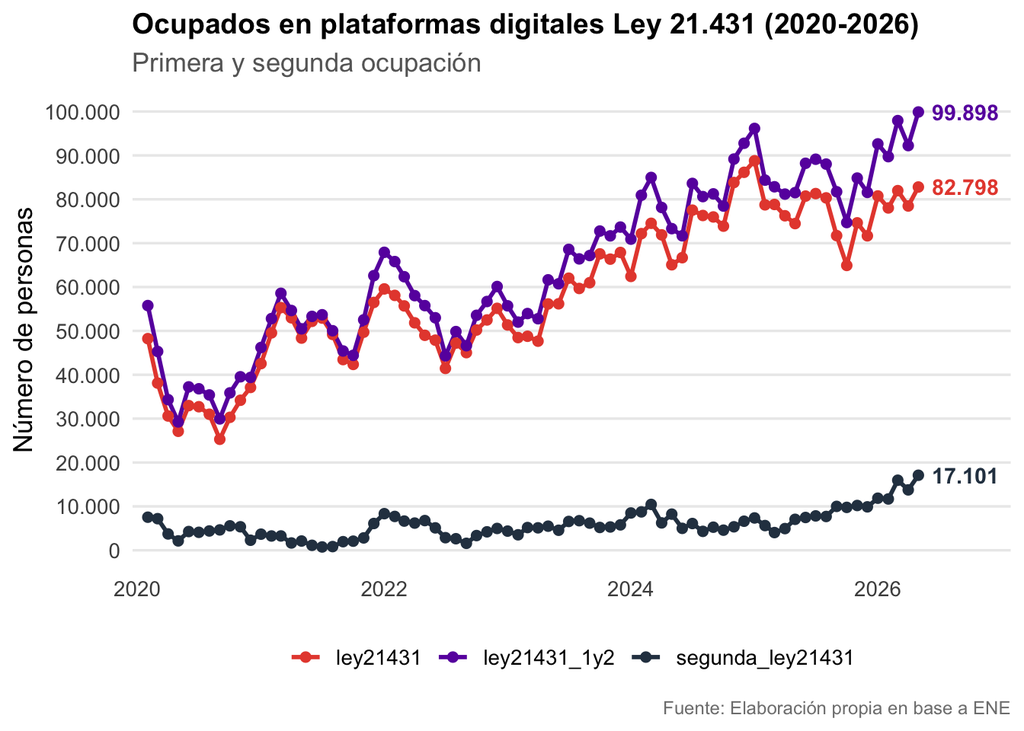

# 5 Empresas de plataformas reguladas por la Ley 21.431 con mayor crecimiento últimos 4 años

Un primer grupo de empresas registra crecimiento desde cero ocupados en 2022 a valores positivos en 2026, entre las que destacan FLEXIT (964), ZUBALE (431), BOOSMAP (414), PICKER UP (304), ENCUADRADO (413), JUMBO SHOPPERS (407) y VALDISHOPPER (389), entre otras con valores menores.

Entre las empresas con presencia en ambos períodos, MERCADOLIBRE presenta la mayor variación porcentual positiva, pasando de 445 a 3.732 ocupados (+738%), seguida por DIDI y UBER EATS. En el otro extremo, Rappi, PedidosYa y Transvip reportan las principales caídas.

Un grupo de empresas pasó de tener ocupados en 2022 a cero en 2026, con una variación de -100%: YAPO.CL, BEAT, CORNERSHOP, SAWU FIVER y FOXER.

Tabla 12: Empresas de plataformas Ley 21431 con mayor crecimiento últimos 4 años

| pd_especifique | 2022-05-01 | 2026-05-01 | variacion_porc |
| --- | --- | --- | --- |
| UBER EATS UBER | 0 | 1890 | Inf |
| FLEXIT | 0 | 964 | Inf |
| DIDI CABIFY INDRIVE | 0 | 712 | Inf |
| MERCADOLIBRE INSTAGRAM | 0 | 544 | Inf |
| ZUBALE | 0 | 431 | Inf |
| BOOSMAP | 0 | 414 | Inf |
| ENCUADRADO | 0 | 413 | Inf |
| JUMBO SHOPPERS | 0 | 407 | Inf |
| VALDISHOPPER | 0 | 389 | Inf |
| PICKER UP | 0 | 304 | Inf |
| META ADS | 0 | 258 | Inf |
| TIKTOK INSTAGRAM | 0 | 243 | Inf |
| INDRIVE WHATSAPP | 0 | 230 | Inf |
| AMIDA VALDISHOPPER | 0 | 224 | Inf |
| PEDIDOS YA WHATSAPP | 0 | 208 | Inf |
| FIVERR | 0 | 200 | Inf |
| WHATSAPP PEDIDOS YA | 0 | 191 | Inf |
| WHATSAPP INSTAGRAM FACEBOOK TIKTOK | 0 | 174 | Inf |
| INSTAGRAM TIKTOK WHATSAPP | 0 | 174 | Inf |
| WHATSAPP INDRIVE | 0 | 151 | Inf |
| INSTAGRAM BOOKING AIRBNB WHATSAPP | 0 | 147 | Inf |
| INSTAGRAM FACEBOOK MERCADOLIBRE | 0 | 139 | Inf |
| WHATSAPP FACEBOOK MARKETPLACE | 0 | 132 | Inf |
| WHATSAPP FACEBOOK YAPO.CL | 0 | 50 | Inf |
| MARKETPLACE WHATSAPP | 0 | 49 | Inf |
| MERCADOLIBRE | 445 | 3732 | 738.7 |
| DIDI | 1208 | 6072 | 402.6 |
| UBER EATS | 1818 | 6669 | 266.8 |
| AMIDA | 192 | 451 | 134.9 |
| UBER | 21503 | 46830 | 117.8 |
| CABIFY | 345 | 701 | 103.2 |
| WHATSAPP UBER | 117 | 236 | 101.7 |
| INDRIVE | 2256 | 2637 | 16.9 |
| PEDIDOS YA | 4114 | 3935 | -4.4 |
| TRANSVIP | 219 | 177 | -19.2 |
| RAPPI | 3592 | 1939 | -46.0 |
| UBER DIDI | 749 | 378 | -49.5 |
| DIDI UBER | 348 | 0 | -100.0 |
| YAPO.CL | 49 | 0 | -100.0 |
| BEAT | 987 | 0 | -100.0 |
| CORNERSHOP | 6647 | 0 | -100.0 |
| SAWU | 894 | 0 | -100.0 |
| FIVER | 620 | 0 | -100.0 |
| FOXER | 2573 | 0 | -100.0 |
| YAPO.CL FACEBOOK | 320 | 0 | -100.0 |

## Notas

[^1]: https://www.ine.gob.cl/docs/default-source/buenas-practicas/clasificaciones/ciuo/clasificador/ciuo-08-cl.pdf